# **Analysis of Africa’s 250 Largest Companies Using Libreoffice Calc and Python**

# 6 **Data Exploration**

## 6.1 **Variables, Observations, and Data Types**

Lets us check the variables and observations present in the data. There are 250 observations of 9 variables.

````markdown
```{python}
africa.info()
```
````

```
<class 'pandas.core.frame.DataFrame'>
RangeIndex: 250 entries, 0 to 249
Data columns (total 12 columns):
 #   Column             Non-Null Count  Dtype
---  ------             --------------  -----
 0   index              250 non-null    int64
 1   ranking2023        250 non-null    int64
 2   ranking2022        226 non-null    float64
 3   name               250 non-null    object
 4   sector             250 non-null    object
 5   stock_exchange     250 non-null    object
 6   market_value_22    246 non-null    float64
 7   market_value23     250 non-null    int64
 8   revenue_latest     171 non-null    float64
 9   net_income_latest  175 non-null    float64
 10  mv_rise            246 non-null    float64
 11  ps_rise            226 non-null    float64
dtypes: float64(6), int64(3), object(3)
memory usage: 23.6+ KB
```

The variables in the data are the following.

````markdown
```{python}
africa.columns.values
```
````

```
array(['index', 'ranking2023', 'ranking2022', 'name', 'sector',
       'stock_exchange', 'market_value_22', 'market_value23',
       'revenue_latest', 'net_income_latest', 'mv_rise', 'ps_rise'],
      dtype=object)
```

- `Ranking2023`: The company ranking by market value in 2023.
- `Ranking2022`: The company ranking by market value in 2022.
- `Name`: The company name.
- `Sector`: The company sector of business operations.
- `Stock exchange`: The stock exchange where company stocks are listed.
- `Market_value_22`: The company market value in 2022.
- `Market_value_23`: The company market value in 2023.
- `Revenue_latest`: Latest reported company annual revenues.
- `Net_income_latest`: Latest reported company net income.

````markdown
```{python}
africa.info()
```
````

```
<class 'pandas.core.frame.DataFrame'>
RangeIndex: 250 entries, 0 to 249
Data columns (total 12 columns):
 #   Column             Non-Null Count  Dtype
---  ------             --------------  -----
 0   index              250 non-null    int64
 1   ranking2023        250 non-null    int64
 2   ranking2022        226 non-null    float64
 3   name               250 non-null    object
 4   sector             250 non-null    object
 5   stock_exchange     250 non-null    object
 6   market_value_22    246 non-null    float64
 7   market_value23     250 non-null    int64
 8   revenue_latest     171 non-null    float64
 9   net_income_latest  175 non-null    float64
 10  mv_rise            246 non-null    float64
 11  ps_rise            226 non-null    float64
dtypes: float64(6), int64(3), object(3)
memory usage: 23.6+ KB
```

## 6.2 **Missing Values**

We examine the missing values in the variables. For the rankings, all the missing values relate to new entrants in the data. For instance, a company may have entered the list of 250 companies in 2023. Hence, ranking for 2022 is a missing value. Likewise, a company may hae been ranked in 2022 but dropped out of the ranking of 250 companies in 2023.

````markdown
```{python}
[col for col in africa.columns if africa[col].isnull().any()]
```
````

```
['ranking2022',
 'market_value_22',
 'revenue_latest',
 'net_income_latest',
 'mv_rise',
 'ps_rise']
```

We see the columns that have missing values. Our interest is in revenues and net income.

````markdown
```{python}
africa.isna().sum()
```
````

```
index                 0
ranking2023           0
ranking2022          24
name                  0
sector                0
stock_exchange        0
market_value_22       4
market_value23        0
revenue_latest       79
net_income_latest    75
mv_rise               4
ps_rise              24
dtype: int64
```

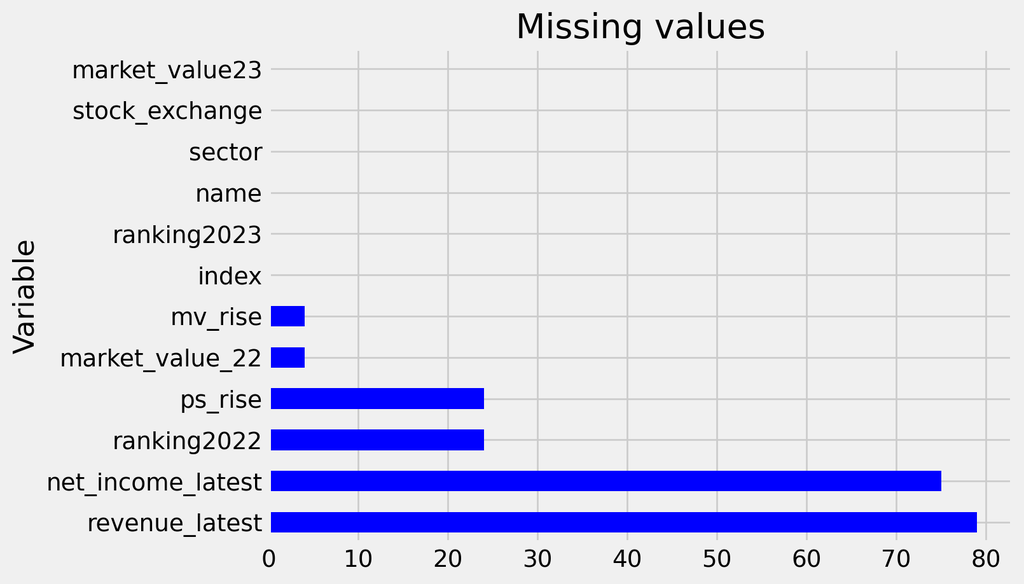

````markdown
```{python}
plt.style.use("fivethirtyeight")
africa.isna().sum().sort_values(ascending=False).plot(kind = "barh",
title = "Missing values", color = "blue")
plt.ylabel("Variable")
plt.show()
```
````

## 6.3 **Data Exploration**

We explore the data using the seaborn pairs plots. The first analysis visualises pertinent variables by country.

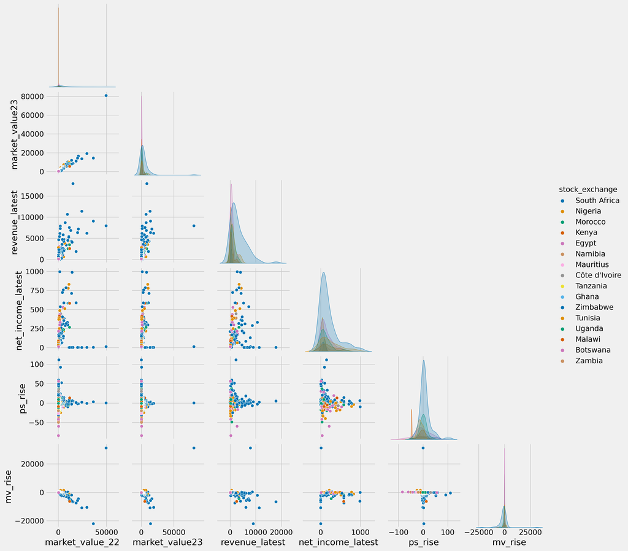

````markdown
```{python}
sns.pairplot(africa[["stock_exchange", "sector", "market_value_22", "market_value23",
"revenue_latest", "net_income_latest", "ps_rise", "mv_rise"]], hue = "stock_exchange", palette = "colorblind", corner = True, dropna = True)
```
````

Let us the same analysis for market sectors. Again we see the variation across sectors.

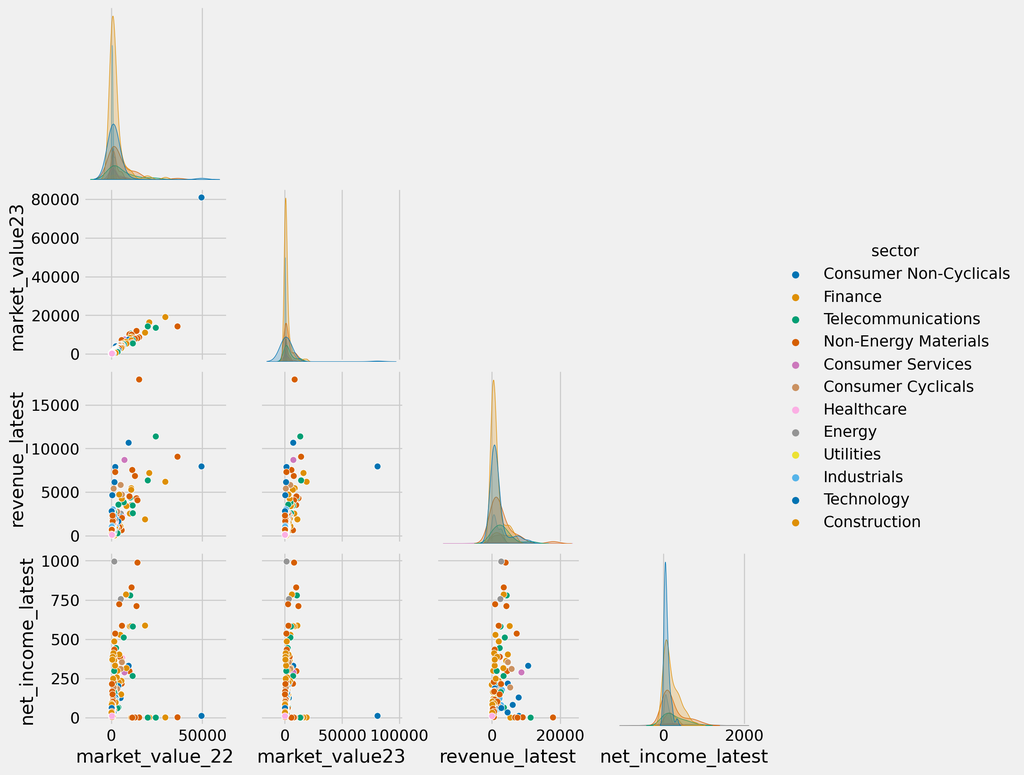

````markdown
```{python}
sns.pairplot(africa[["stock_exchange", "sector", "market_value_22", "market_value23",
"revenue_latest", "net_income_latest"]], hue = "sector", palette = "colorblind", corner = True, dropna = True)
```
````

# 7 **Answering Pertinent Questions**

## 7.1 Which are the top 20 ranked companies in Africa?

In this section, I concentrate on the top 20 companies in Africa. The top company for 2 years running is `Naspers` of South Africa, a company dealing in consumer non-cyclicals. First Rand Bank and Standard Bank Group from South Africa come a distant second.

````markdown
```{python}
africa[["name","sector","stock_exchange",
"market_value_22","market_value23",
"revenue_latest", "net_income_latest"]].head(20)
```
````

|  | name | sector | stock_exchange | market_value_22 | market_value23 | revenue_latest | net_income_latest |
| --- | --- | --- | --- | --- | --- | --- | --- |
| 0 | Naspers | Consumer Non-Cyclicals | South Africa | 49619.0 | 80865 | 7940.0 | 12.0 |
| 1 | FirstRand | Finance | South Africa | 29739.0 | 19090 | 6178.0 | 2.0 |
| 2 | Standard Bank Group | Finance | South Africa | 20915.0 | 16347 | 7183.0 | 2.0 |
| 3 | Vodacom Group | Telecommunications | South Africa | 20102.0 | 14292 | 6334.0 | 1.0 |
| 4 | Anglo American Platinum | Non-Energy Materials | South Africa | 36429.0 | 14265 | 9056.0 | 3.0 |
| 5 | MTN Group | Telecommunications | South Africa | 24500.0 | 13537 | 11381.0 | 1.0 |
| 6 | Gold Fields | Non-Energy Materials | South Africa | 13909.0 | 11936 | 4287.0 | 711.0 |
| 7 | Capitec Bank Holdings | Finance | South Africa | 18604.0 | 11044 | 1861.0 | 587.0 |
| 8 | MTN Nigeria | Telecommunications | Nigeria | 10471.0 | 10602 | 4370.0 | 779.0 |
| 9 | AngloGold Ashanti | Non-Energy Materials | South Africa | 10032.0 | 10196 | 4501.0 | 297.0 |
| 10 | Dangote Cement | Non-Energy Materials | Nigeria | 11203.0 | 9986 | 3512.0 | 830.0 |
| 11 | Absa Group | Finance | South Africa | 11048.0 | 8686 | 5438.0 | 1.0 |
| 12 | Sasol | Non-Energy Materials | South Africa | 15354.0 | 8638 | 17920.0 | 2.0 |
| 13 | Attijariwafa Bank | Finance | Morocco | 10250.0 | 8335 | 2528.0 | 582.0 |
| 14 | Kumba Iron Ore | Non-Energy Materials | South Africa | 14446.0 | 8163 | 4058.0 | 988.0 |
| 15 | Impala Platinum Holdings | Non-Energy Materials | South Africa | 13062.0 | 7874 | 6842.0 | 2.0 |
| 16 | Bid Corp | Consumer Services | South Africa | 7300.0 | 7533 | 8686.0 | 289.0 |
| 17 | Shoprite Holdings | Consumer Non-Cyclicals | South Africa | 9577.0 | 7408 | 10658.0 | 331.0 |
| 18 | Maroc Telecom | Telecommunications | Morocco | 11782.0 | 7307 | 3454.0 | 266.0 |
| 19 | BUA Cement | Non-Energy Materials | Nigeria | 5759.0 | 7192 | 620.0 | 217.0 |

Notable is that 15 of the companies in the top 20 are from South Africa. That is a ratio of 75%.

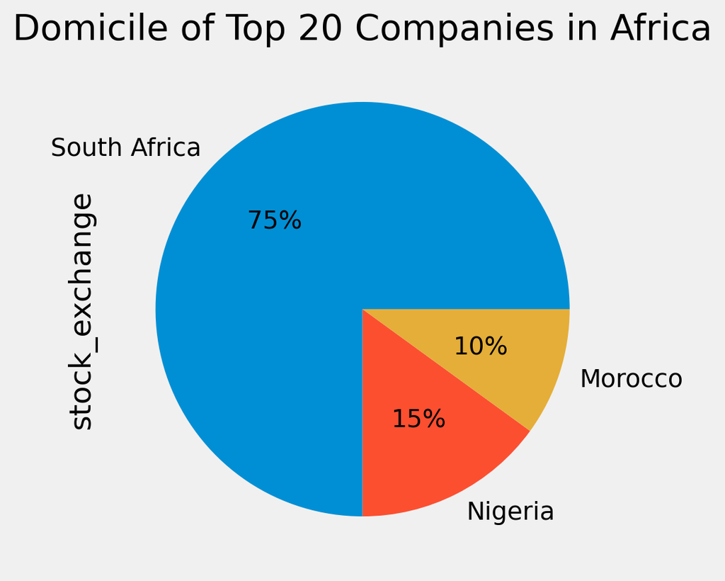

````markdown
```{python}
africa[["name","sector","stock_exchange",
"market_value_22","market_value23",
"revenue_latest", "net_income_latest"]].head(20)["stock_exchange"].value_counts().plot(kind = "pie", title = "Domicile of Top 20 Companies in Africa", autopct = "%1.0f%%")
```
````

Which industries have the most companies in the top 20? The chart below shows shows that companies in the non-energy materials and finance dominate the top 20 with 40% and 25% shares, respectively.

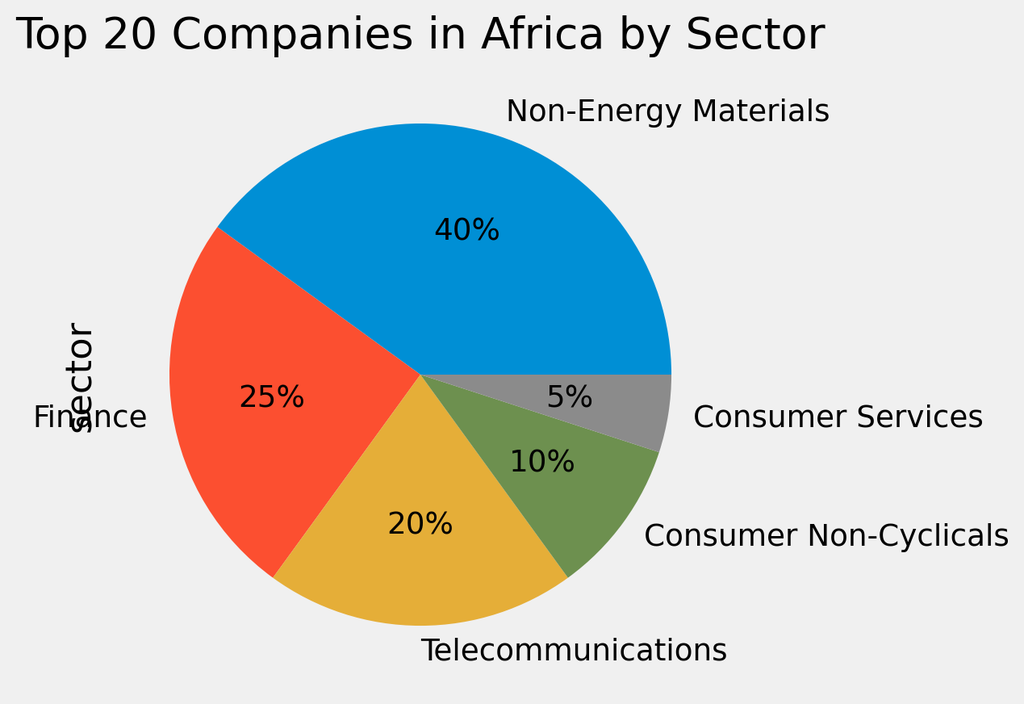

````markdown
```{python}
africa[["name","sector","stock_exchange",
"market_value_22","market_value23",
"revenue_latest", "net_income_latest"]].head(20)["sector"].value_counts().plot(kind = "pie", title = "Top 20 Companies in Africa by Sector", autopct = "%1.0f%%")
```
````

## 7.2 Which are the top 20 ranked companies in Africa (Outside South Africa)?

Given the dominance of South Africa in the sample, I create a subset of data that excludes companies from South Africa and rerun the analysis.The aim is to list the top 20 companies in Africa not domiciled in South Africa.

````markdown
```{python}
africa[africa["stock_exchange"] != "South Africa"][["name", "stock_exchange"]].head(20)
```
````

|  | name | stock_exchange |
| --- | --- | --- |
| 8 | MTN Nigeria | Nigeria |
| 10 | Dangote Cement | Nigeria |
| 13 | Attijariwafa Bank | Morocco |
| 18 | Maroc Telecom | Morocco |
| 19 | BUA Cement | Nigeria |
| 24 | Safaricom | Kenya |
| 26 | Commercial International Bank | Egypt |
| 27 | Airtel Africa | Nigeria |
| 30 | Banque Centrale Populaire | Morocco |
| 32 | B2gold Corp | Namibia |
| 33 | BUA Foods | Nigeria |
| 38 | Afreximbank (DRs) | Mauritius |
| 39 | Bank of Africa (formerly BMCE) | Morocco |
| 42 | LafargeHolcim Maroc | Morocco |
| 47 | Sonatel | Côte d'Ivoire |
| 50 | Managem | Morocco |
| 52 | Orange Côte d'Ivoire | Côte d'Ivoire |
| 55 | TAQA Morocco | Morocco |
| 59 | Nestle Nigeria | Nigeria |
| 61 | Abou Kir Fertilizers & Chemicals | Egypt |

We see that Morocco, Nigeria, and Egypt top the list.

````markdown
```{python}
africa[africa["stock_exchange"] != "South Africa"][["name", "stock_exchange"]].head(20)["stock_exchange"].value_counts()
```
````

```
Morocco          7
Nigeria          6
Egypt            2
Côte d'Ivoire    2
Kenya            1
Namibia          1
Mauritius        1
Name: stock_exchange, dtype: int64
```

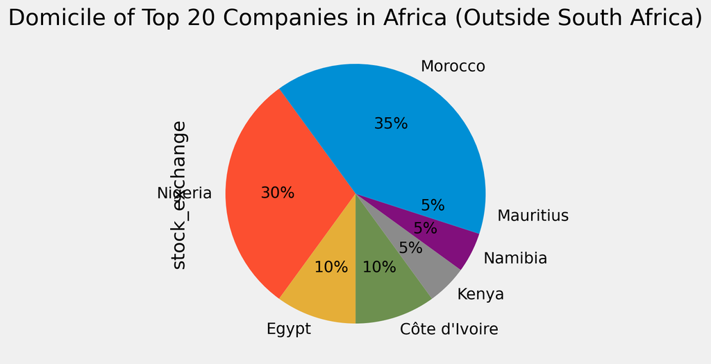

````markdown
```{python}
africa[africa["stock_exchange"] != "South Africa"][["name", "stock_exchange"]].head(20)["stock_exchange"].value_counts().plot(kind = "pie", title = "Domicile of Top 20 Companies in Africa (Outside South Africa)", autopct = "%1.0f%%")
```
````

Outside South Africa, telecommunications, non-energy materials, and finance are the dominant sectors for the top 20 companies.

````markdown
```{python}
africa[africa["stock_exchange"] != "South Africa"][["name", "sector"]].head(20)["sector"].value_counts()
```
````

```
Telecommunications        6
Non-Energy Materials      6
Finance                   5
Consumer Non-Cyclicals    2
Utilities                 1
Name: sector, dtype: int64
```

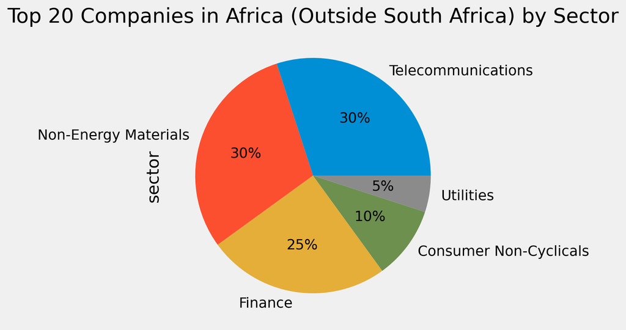

````markdown
```{python}
africa[africa["stock_exchange"] != "South Africa"][["name", "sector"]].head(20)["sector"].value_counts().plot(kind = "pie", title = "Top 20 Companies in Africa (Outside South Africa) by Sector", autopct = "%1.0f%%")
```
````

## 7.3 Which countries have the highest concentration of companies in the top 250 largest corporations in Africa?

In the previous section, we concentrated on the top 20 largest companies. Here, we examine the entire sample data. Which country has the largest number of companies in the top 250?

We see that South Africa still leads with 38%, followed by Egypt(13%), Morocco (12%), Nigeria and Kenya (9% and 4% respectively).

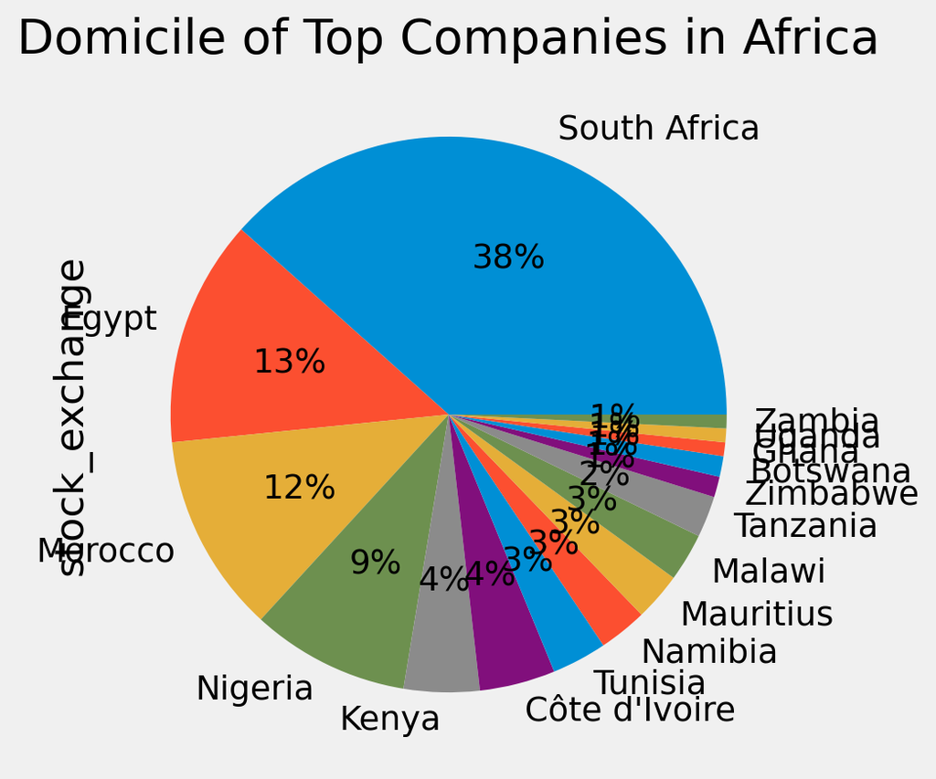

````markdown
```{python}
africa["stock_exchange"].value_counts().plot(kind = "pie", title = "Domicile of Top Companies in Africa", autopct = "%1.0f%%")
```
````

## 7.4 Which industries have the highest concentration of companies in the top 250 largest corporations in Africa?

Which industries dominate Africa’s corporate landscape? The figure below that in Africa, the financial sector leads by a wide margin, followed by consumer non-cyclicals, non-energy materials and telecommunications. Perhaps most companies engaged in cosntruction,health, and health care are from outside the continent. There is room fo further analysis.

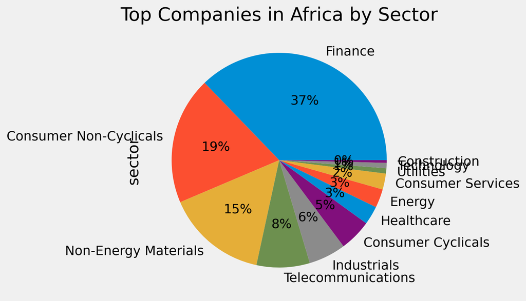

````markdown
```{python}
africa["sector"].value_counts().plot(kind = "pie", title = "Top Companies in Africa by Sector", autopct = "%1.0f%%")
```
````

## 7.5 What is the correlation between market value of a company on the one hand and revenues and profits on the other?

Among the 250 largest companies in Africa, revenues have a stronger correlation with the market value of a company than profits. Although profits do consist of numerous non-cash expenditures, this observation is surprising, especially given that profits have a very mild correlation with the market value of a company.

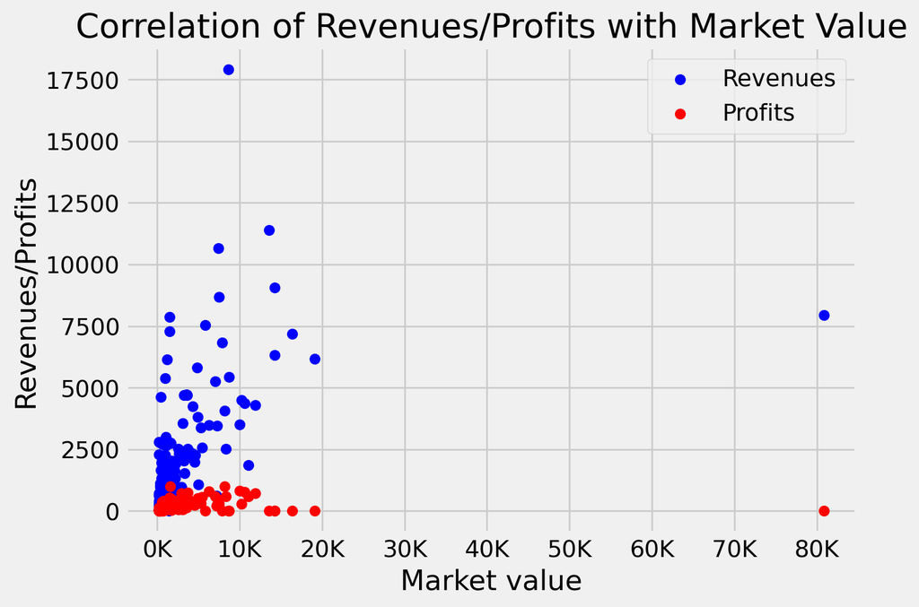

````markdown
```{python}
plt.scatter(africa["market_value23"],
africa["revenue_latest"], color = "blue",
label = "Revenues")

plt.scatter(africa["market_value23"],
africa["net_income_latest"], color = "red", label = "Profits")

plt.legend()
plt.xlabel("Market value")
plt.ylabel("Revenues/Profits")
plt.title("Correlation of Revenues/Profits with Market Value")
plt.xticks([0, 10000, 20000, 30000, 40000, 50000, 60000, 70000, 80000],
labels = ["0K", "10K", "20K", "30K", "40K", "50K", "60K", "70K", "80K"])
plt.show()
```
````

## 7.6 Which company has the highest rise in market value between 2022 and 2023.

Let us examine companies that had the highest rise in market value beyween 2022 and 2023. We see that Naspers had a stageering USD 31,246,000,000 rise in market value between 2022 and 2023. Bua cement comes a distant second. It would be interesting to examine the meteoric rise of Nasper.

````markdown
```{python}
africa.nlargest(10, "mv_rise")[["name", "stock_exchange", "mv_rise"]]
```
````

|  | name | stock_exchange | mv_rise |
| --- | --- | --- | --- |
| 0 | Naspers | South Africa | 31246.0 |
| 19 | BUA Cement | Nigeria | 1433.0 |
| 33 | BUA Foods | Nigeria | 1410.0 |
| 50 | Managem | Morocco | 422.0 |
| 93 | Banque Internationale Arabe de Tunisie (BIAT) | Tunisia | 296.0 |
| 103 | Hosken Consolidated Investments | South Africa | 278.0 |
| 118 | National Bank of Malawi | Malawi | 264.0 |
| 156 | Illovo Sugar (Malawi) | Malawi | 256.0 |
| 117 | Airtel Malawi | Malawi | 241.0 |
| 16 | Bid Corp | South Africa | 233.0 |

Of importance is the percentage rise in market valuation.

````markdown
```{python}
africa["perc_mv_rise"] = africa["mv_rise"]/africa["market_value_22"] * 100
```
````

````markdown
```{python}
africa.nlargest(10, "perc_mv_rise")[["name","stock_exchange", "perc_mv_rise"]]
```
````

|  | name | stock_exchange | perc_mv_rise |
| --- | --- | --- | --- |
| 230 | FDH Bank | Malawi | 100.763359 |
| 218 | Abu Dhabi Islamic Bank – Egypt | Egypt | 96.710526 |
| 156 | Illovo Sugar (Malawi) | Malawi | 95.880150 |
| 158 | Sidi Kerir Petrochemicals | Egypt | 68.666667 |
| 183 | FMB Capital Holdings | Malawi | 66.390041 |
| 0 | Naspers | South Africa | 62.971845 |
| 33 | BUA Foods | Nigeria | 54.757282 |
| 245 | Union Internationale de Banques | Tunisia | 52.830189 |
| 205 | Fidelity Bank | Nigeria | 50.672646 |
| 118 | National Bank of Malawi | Malawi | 48.708487 |

The analysis shows that FDH bank of Malawi more than doubled its market value between 2022 and 2023. That is phenomenal. Investors must have laughed all the way to the bank. Notably, only one company in South Africa appears on this list. The observation suggests that there is greater room for growth outside South Africa.

````markdown
```{python}
africa.nlargest(10, "ps_rise")[["name", "stock_exchange", "ps_rise"]]
```
````

|  | name | stock_exchange | ps_rise |
| --- | --- | --- | --- |
| 247 | Arcelormittal South Africa | South Africa | 111.0 |
| 151 | Transaction Capital | South Africa | 92.0 |
| 241 | Cashbuild | South Africa | 59.0 |
| 249 | Cleopatra Hospital | Egypt | 56.0 |
| 233 | Raubex Group | South Africa | 54.0 |
| 98 | Econet Wireless | Zimbabwe | 52.0 |
| 154 | Innscor Africa* | Zimbabwe | 52.0 |
| 175 | KAP Industrial Holdings | South Africa | 51.0 |
| 238 | PPC | South Africa | 49.0 |
| 211 | National Bank of Kuwait – Egypt | Egypt | 47.0 |

# 8 **Conclusion**

More analysis is warranted to identify drivers of business performance on the continent.

## References

Borjigin, C. (2023). *Python data science*. Springer Nature Singapore. https://doi.org/10.1007/978-981-19-7702-2

Kagle. (2023). *Top 2000 companies globally*. https://www.kaggle.com/datasets/joebeachcapital/top-2000-companies-globally.

VanderPlas, J. (2016). *Python data science handbook: Essential tools for working with data*. " O’Reilly Media, Inc.".

## Footnotes

[^1]: The data is available on this link https://african.business/2023/05/long-reads/africas-top-250-companies-in-2023-doing-business-in-tough-times
[^2]: Libreoffice is available to download,install and use on the site https://www.libreoffice.org/